# Visualisation with ggplot

# 3 numeric features (with one >0)

# + categories

## Scatter plot + color + size

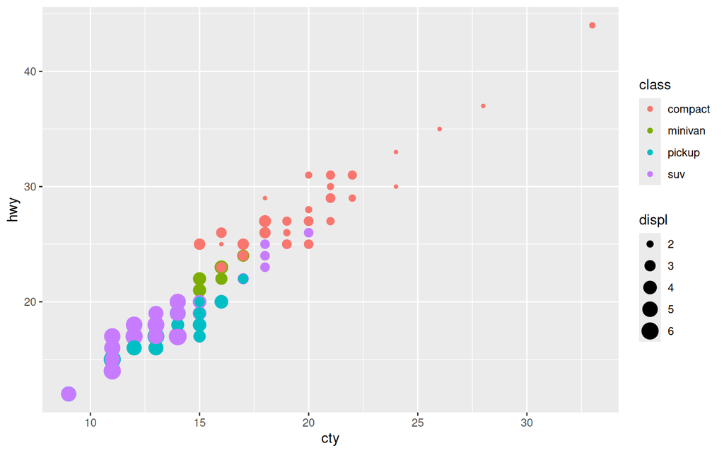

```r
ggplot(mpg_su)+geom_point(aes(x=cty,y=hwy,color=class,size=displ))
```

## Scatter plot + color + size ! scales

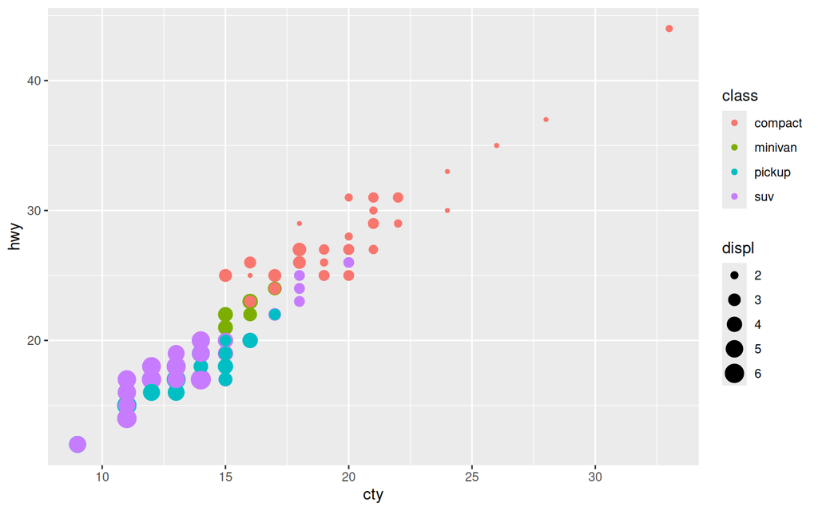

```r
ggplot(mpg_su)+geom_point(aes(x=cty,y=hwy,color=class,size=displ))
```

# Circle size : radius or area ?

#### Rayon

#### Aire

## Color scales

https://colorbrewer2.org

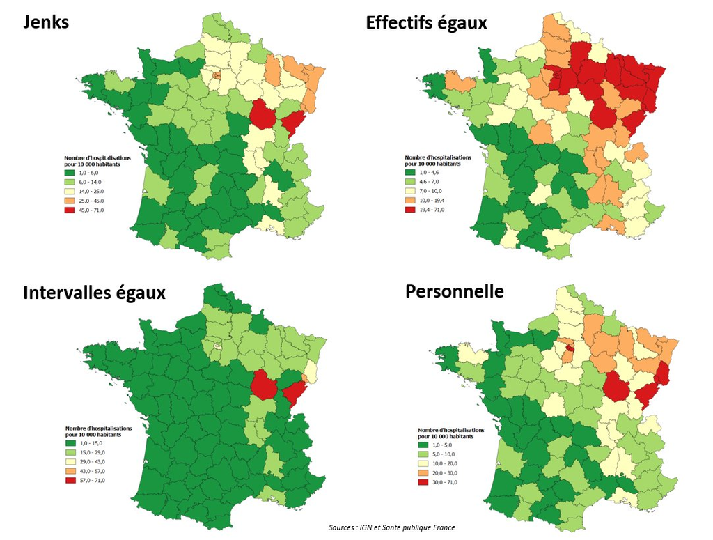

color scheme + discretisation

## Color scales

https://colorbrewer2.org

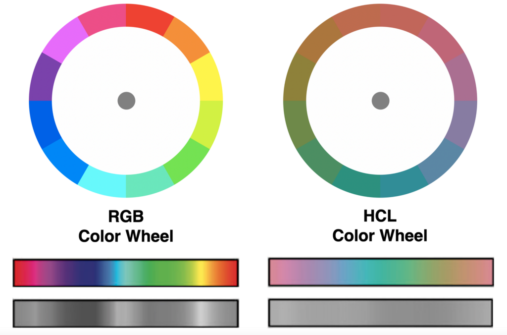

color scheme + interpolation (! color space)

## More complex graphics

https://www.data-to-viz.com/

ex: More than 3 continuous variables ?

## More complex graphics

https://www.data-to-viz.com/

ex: More than 3 continuous variables ?

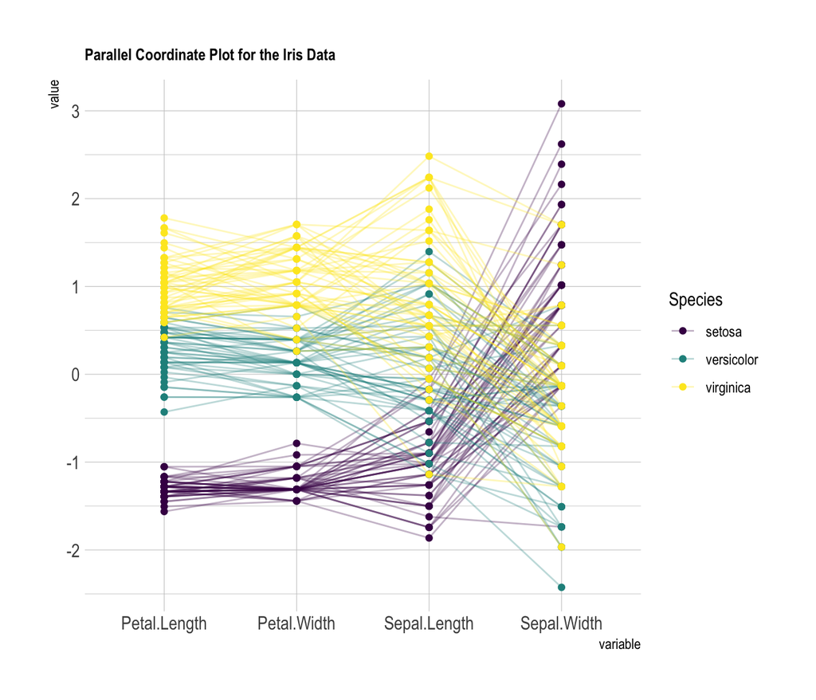

Parallel plot

## More complex graphics

https://www.data-to-viz.com/

ex: Multimodal distributions ?

## More complex graphics

https://www.data-to-viz.com/

ex: Multimodal distributions ?

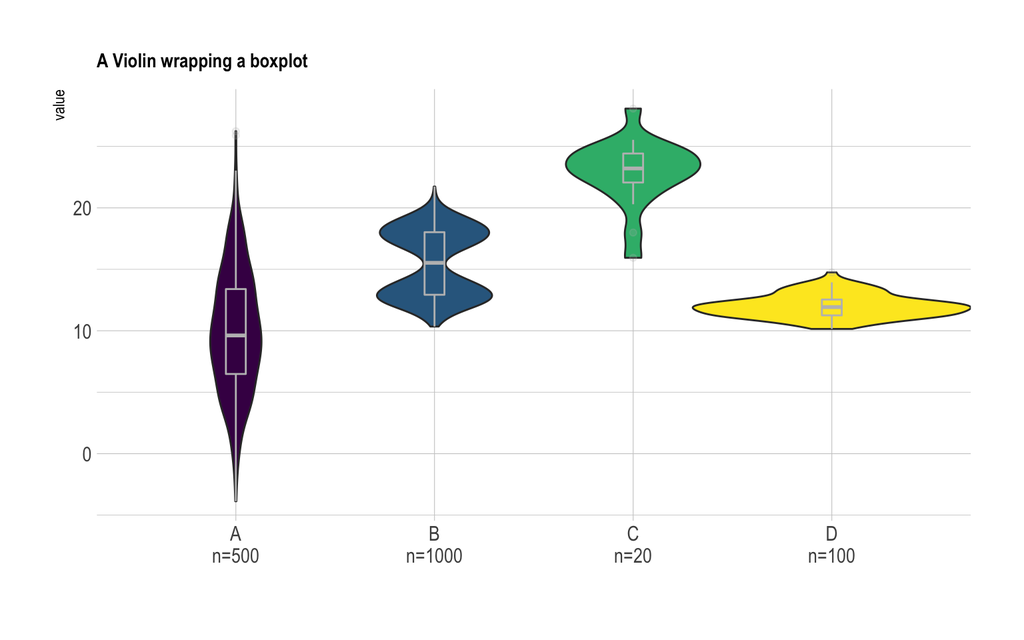

Violin plot

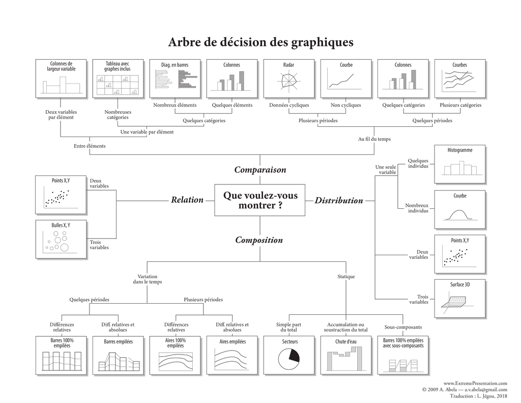

## Tufte

## Data-ink ratio

## Lying factor

# Principle :

$$\textrm{Lie factor} =
\frac{\textrm{visual effect size}}{\textrm{data effect
size}}$$

# Lie factor :

$$\textrm{data effect size} = \frac{27.5 -
18}{18} \times 100 = 53 \%$$

#### Edward Tufte, The Visual Display of Quantitative Information, Cheshire, CT, Graphics Press, 2001, 2e éd. (1re éd. 1983)

# Lie factor :

$$\textrm{visual effect size} = \frac{5.3
-0.6}{0.6} \times 100 = 783 \%$$

#### Edward Tufte, The Visual Display of Quantitative Information, Cheshire, CT, Graphics Press, 2001, 2e éd. (1re éd. 1983)

# Lie factor :

$$\textrm{Lie factor} = \frac{783}{53} =
14.8$$

#### Edward Tufte, The Visual Display of Quantitative Information, Cheshire, CT, Graphics Press, 2001, 2e éd. (1re éd. 1983)

# Lie factor : 9.4

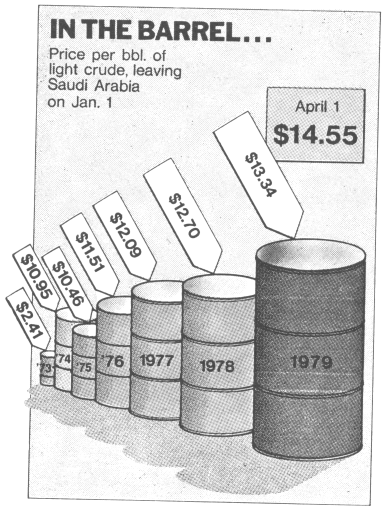

#### Edward Tufte, The Visual Display of Quantitative Information, Cheshire, CT, Graphics Press, 2001, 2e éd. (1re éd. 1983)

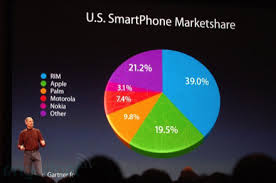

knowing that the “apple”” area (in green ) is equal to $2.22\,cm^2$ and that the rim area (in blue) is equal to $2.96\,cm^2$ compute the lyong factor ?

## Perception

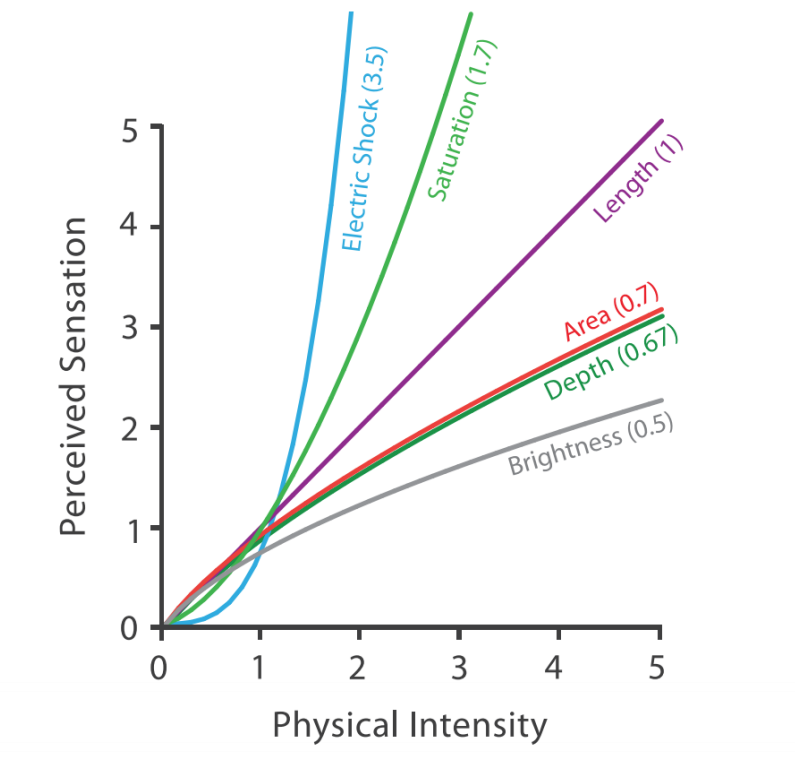

$$S = I^p$$

# Principle :

# Increase the data density

$$\textrm{graph data density} =
\frac{\textrm{number of entries in data matrix}}{\textrm{area of data
display}}$$

# Data density :

#### Avoid graphics with low data density

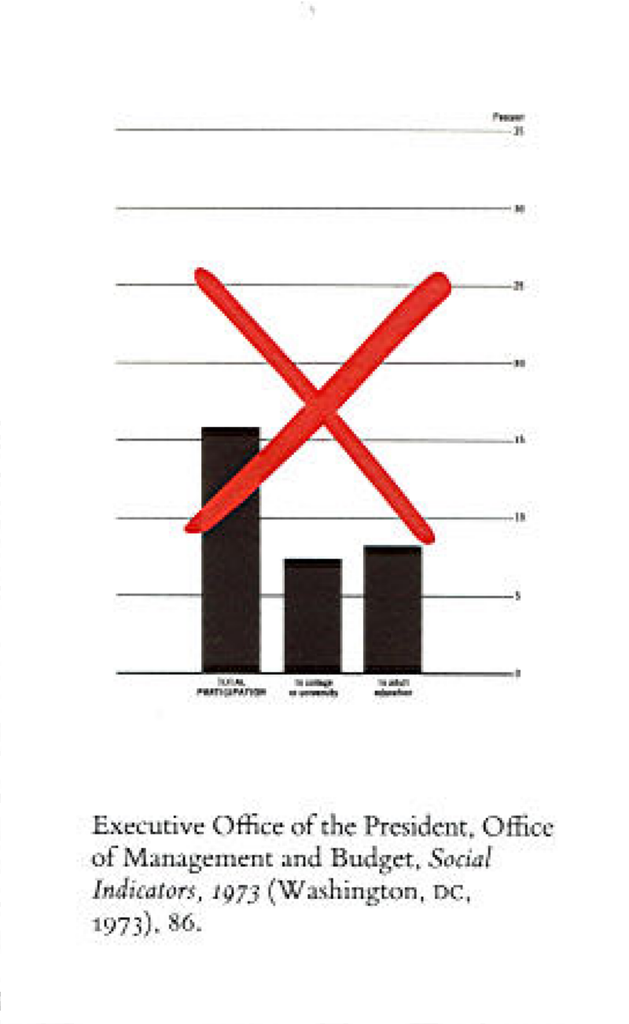

#### Edward Tufte, The Visual Display of Quantitative Information, Cheshire, CT, Graphics Press, 2001, 2e éd. (1re éd. 1983)

# Data density :

#### Avoid graphics with low data density

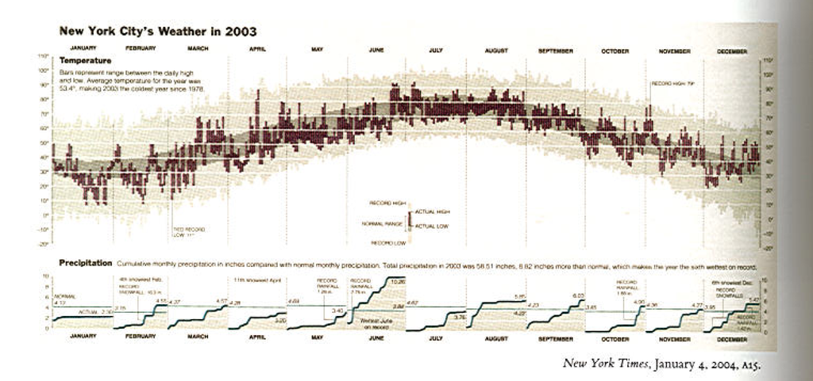

#### Edward Tufte, The Visual Display of Quantitative Information, Cheshire, CT, Graphics Press, 2001, 2e éd. (1re éd. 1983)

# Principle :

# Increase the data-ink ratio

$$\textrm{data-ink ratio} =
\frac{\textrm{area of data-ink}}{\textrm{total area of
ink}}$$

# Data-ink ratio :

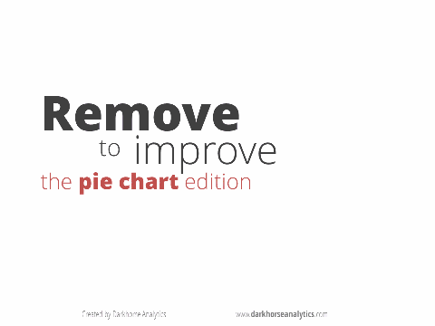

# Data-ink ratio :

#### Remove to improve

https://speakerdeck.com/cherdarchuk/remove-to-improve-the-data-ink-ratio

# Data-ink ratio :

#### Remove to improve

https://www.youtube.com/watch?v=bDbJBWvonVI

## Recap

- Avoid misleading graphics !
- Avoid empty graphics
- Be parsimonius with ink
- Scales !, (!colors, !size)
- Use explicit labels and
- ! categorial features and order
- aspect ratio
- filetype pdf, svg // png,jpg

## ggplot

# gg = grammar of graphics

- “The Grammar of Graphics” (Wilkinson, Annand and Grossman, 2005)
- grammar → same language for all figures

## ggplot

#### building blocks of the grammar

- the coordinate system
- data and aesthetic mappings,  
  ex : f(data) → x position, y position, size, shape, color
- geometric objects,  
  ex : points, lines, bars, texts
- scales,  
  ex : f([0, 100]) → [0, 5] px
- facet specification,  
  ex : split the data into several plots
- statistical transformations,  
  ex : average, coounting, regression

## ggplot

#### Make a graphic :

- add several layers
- with their own visual encoding and possibly their own data
- (+ optional) add statistical transformation
- (+ optional) change scale options
- (+ optional) specify title, theme, guides, style …

#### ! data = tidy data.frame with the right feature types

## ggplot, géométries

#### Make a graphic :

- add several layers

  ```r
  +geom_line()
  ```

- with their own visual encoding and possibly their own data

  ```r
  aes(x=a,y=b,...)
  ```

#### Exemple

```r
ggplot(mpg)+
  geom_point(aes(x=cty,y=hwy,color=manufacturer,shape=factor(cyl)))
ggplot(mpg,aes(x=cty,y=hwy,color=manufacturer,shape=factor(cyl)))+
  geom_jitter()
```

## ggplot

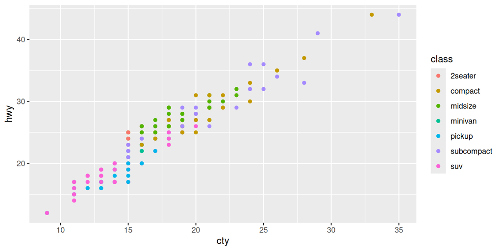

```r
ggplot(mpg,aes(x=cty,y=hwy,color=class))+geom_point()
```

## ggplot

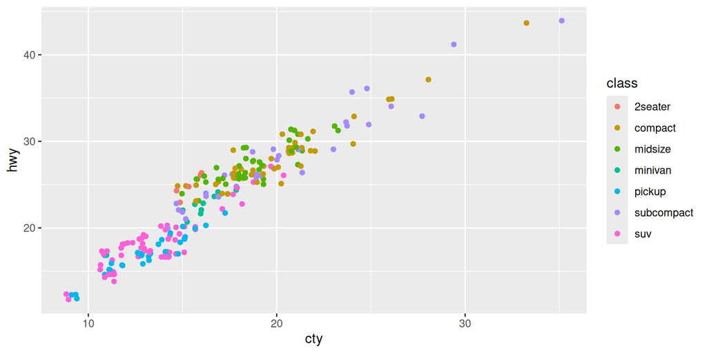

```r
ggplot(mpg,aes(x=cty,y=hwy,color=class))+geom_jitter()
```

## ggplot

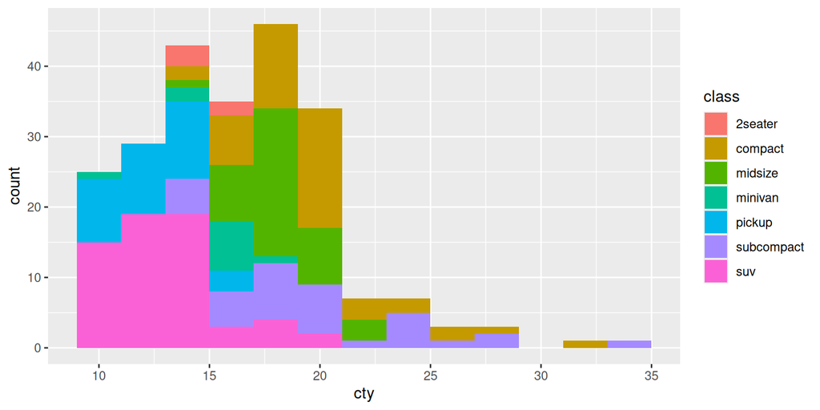

```r
ggplot(mpg,aes(x=cty,fill=class))+geom_histogram(binwidth=2)
```

## ggplot

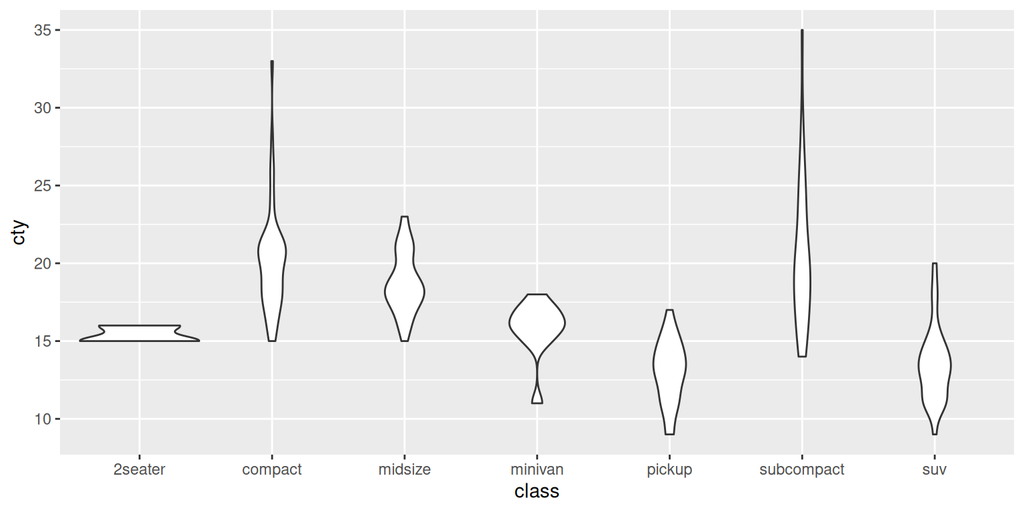

```r
ggplot(mpg,aes(y=cty,x=class))+geom_violin()
```

## ggplot, scales

#### Make a graphic :

- add several layers

  ```r
  +geom_line()
  ```

- with their own visual encoding and possibly their own data

  ```r
  aes(x=a,y=b,...)
  ```

- (+ optionel) change scale options

  ```r
  scale_fill_brewer(palette=3,type="qual")
  scale_x_continuous(limits=c(0,45),breaks=seq(0,45,2))
  ```

## ggplot, scales

[figure not shown]

```r
ggplot(mpg,aes(x=cty,y=hwy,color=manufacturer,shape=factor(cyl)))+
  geom_jitter()+
  scale_x_continuous(limits=c(0,45),breaks=seq(0,45,2))
```

# Colors scales

## ggplot, faceting

#### Make a graphic :

- add several layers

  ```r
  +geom_line()
  ```

- with their own visual encoding and possibly their own data

  ```r
  aes(x=a,y=b,...)
  ```

- (+ optionel) change scale options

  ```r
  scale_fill_brewer(palette=3,type="qual")
  scale_x_continuous(limits=c(0,45),breaks=seq(0,45,2))
  ```

- use facet ?

  ```r
  facet_grid(. ~ cyl)
  ```

## ggplot, faceting

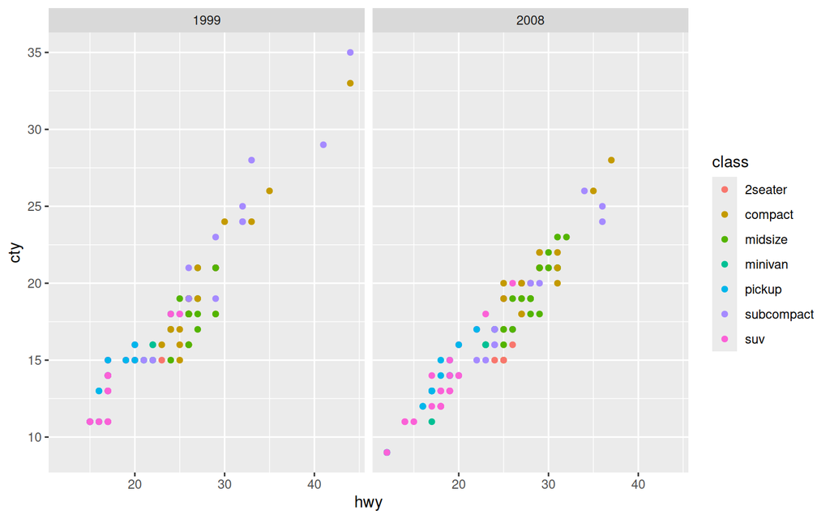

```r
ggplot(data=mpg,aes(x=hwy,y=cty,color=class))+
  geom_point()+
  facet_wrap(~year)
```

## ggplot, stats

#### Make a graphic :

- add several layers

  ```r
  +geom_line()
  ```

- with their own visual encoding and possibly their own data

  ```r
  aes(x=a,y=b,...)
  ```

- (+ optionel) change scale options

  ```r
  scale_fill_brewer(palette=3,type="qual")
  scale_x_continuous(limits=c(0,45),breaks=seq(0,45,2))
  ```

- add statistics

  ```r
  stat_density2d()
  ```

## ggplot

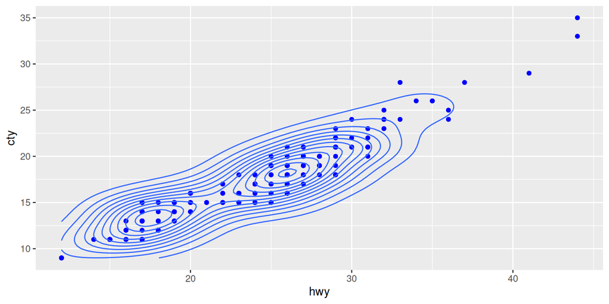

```r
ggplot(mpg,aes(y=cty,x=hwy))+
  geom_point(color="blue")+stat_density2d()
```